# Credit Card Fraud Detection using Naive Bayes, Decision Tree and Random Forests tuning.

Wai Leong

Thanksgiving 2018

## Introduction

It is important that credit card companies are able to recognize fraudulent credit card transactions so that customers are not charged for items that they did not purchase. It is also extremely important for credit card companies to detect and predict future fraud transactions that are genuine before being reported by unhappy customers.

## Objectives

The project objective is to evaluate the performance of NaÃ¯ve Bayes, Decision Tree and Random Forests models on predicting credit card fraud, in terms of Accuracy, CPU time and Negative Predict Value.

## Steps taken.

Initially, Random Forest(RF) was used to train on 75% of the data and after running it on single CPU at peak swapping memory of about 8G and had run more than 12 hours, it was infeasible to train the RF in a reasonable and allowable timeframe.

Multiple CPUs were used to parallelized the models training processes for speedup so that we can observe the overfit and underfit ph if exist.

The training of the Naive Bayes and Decision Tree models were done on 80% of the data. However, the training for Random Forest models were seperated into 10% of the data on runs with 4 cores and 80% on 1 core.

## Final Model Selection.

Lastly, performance parameter like Accuracy and Negative Predicted Value were used to select the appropriate model for this project.

Load the libraries and data

Glancing at data.

```r
str(cc)
```

```
## 'data.frame':    284807 obs. of  31 variables:
##  $ Time  : num  0 0 1 1 2 2 4 7 7 9 ...
##  $ V1    : num  -1.36 1.192 -1.358 -0.966 -1.158 ...
##  $ V2    : num  -0.0728 0.2662 -1.3402 -0.1852 0.8777 ...
##  $ V3    : num  2.536 0.166 1.773 1.793 1.549 ...
##  $ V4    : num  1.378 0.448 0.38 -0.863 0.403 ...
##  $ V5    : num  -0.3383 0.06 -0.5032 -0.0103 -0.4072 ...
##  $ V6    : num  0.4624 -0.0824 1.8005 1.2472 0.0959 ...
##  $ V7    : num  0.2396 -0.0788 0.7915 0.2376 0.5929 ...
##  $ V8    : num  0.0987 0.0851 0.2477 0.3774 -0.2705 ...
##  $ V9    : num  0.364 -0.255 -1.515 -1.387 0.818 ...
##  $ V10   : num  0.0908 -0.167 0.2076 -0.055 0.7531 ...
##  $ V11   : num  -0.552 1.613 0.625 -0.226 -0.823 ...
##  $ V12   : num  -0.6178 1.0652 0.0661 0.1782 0.5382 ...
##  $ V13   : num  -0.991 0.489 0.717 0.508 1.346 ...
```

[output cut: 17 more lines]

```r
head(cc)
```

```
##   Time         V1          V2        V3         V4          V5          V6
## 1    0 -1.3598071 -0.07278117 2.5363467  1.3781552 -0.33832077  0.46238778
## 2    0  1.1918571  0.26615071 0.1664801  0.4481541  0.06001765 -0.08236081
## 3    1 -1.3583541 -1.34016307 1.7732093  0.3797796 -0.50319813  1.80049938
## 4    1 -0.9662717 -0.18522601 1.7929933 -0.8632913 -0.01030888  1.24720317
## 5    2 -1.1582331  0.87773675 1.5487178  0.4030339 -0.40719338  0.09592146
## 6    2 -0.4259659  0.96052304 1.1411093 -0.1682521  0.42098688 -0.02972755
##            V7          V8         V9         V10        V11         V12
## 1  0.23959855  0.09869790  0.3637870  0.09079417 -0.5515995 -0.61780086
## 2 -0.07880298  0.08510165 -0.2554251 -0.16697441  1.6127267  1.06523531
## 3  0.79146096  0.24767579 -1.5146543  0.20764287  0.6245015  0.06608369
## 4  0.23760894  0.37743587 -1.3870241 -0.05495192 -0.2264873  0.17822823
## 5  0.59294075 -0.27053268  0.8177393  0.75307443 -0.8228429  0.53819555
## 6  0.47620095  0.26031433 -0.5686714 -0.37140720  1.3412620  0.35989384
##          V13        V14        V15        V16         V17         V18
```

[output cut: 20 more lines]

Check for empty entry.

```r
anyNA(cc)
```

```
## [1] FALSE
```

```r
summary(cc)
```

```
##       Time              V1                  V2
##  Min.   :     0   Min.   :-56.40751   Min.   :-72.71573
##  1st Qu.: 54202   1st Qu.: -0.92037   1st Qu.: -0.59855
##  Median : 84692   Median :  0.01811   Median :  0.06549
##  Mean   : 94814   Mean   :  0.00000   Mean   :  0.00000
##  3rd Qu.:139321   3rd Qu.:  1.31564   3rd Qu.:  0.80372
##  Max.   :172792   Max.   :  2.45493   Max.   : 22.05773
##        V3                 V4                 V5
##  Min.   :-48.3256   Min.   :-5.68317   Min.   :-113.74331
##  1st Qu.: -0.8904   1st Qu.:-0.84864   1st Qu.:  -0.69160
##  Median :  0.1799   Median :-0.01985   Median :  -0.05434
##  Mean   :  0.0000   Mean   : 0.00000   Mean   :   0.00000
##  3rd Qu.:  1.0272   3rd Qu.: 0.74334   3rd Qu.:   0.61193
##  Max.   :  9.3826   Max.   :16.87534   Max.   :  34.80167
##        V6                 V7                 V8
##  Min.   :-26.1605   Min.   :-43.5572   Min.   :-73.21672
##  1st Qu.: -0.7683   1st Qu.: -0.5541   1st Qu.: -0.20863
##  Median : -0.2742   Median :  0.0401   Median :  0.02236
##  Mean   :  0.0000   Mean   :  0.0000   Mean   :  0.00000
##  3rd Qu.:  0.3986   3rd Qu.:  0.5704   3rd Qu.:  0.32735
##  Max.   : 73.3016   Max.   :120.5895   Max.   : 20.00721
##        V9                 V10                 V11
##  Min.   :-13.43407   Min.   :-24.58826   Min.   :-4.79747
##  1st Qu.: -0.64310   1st Qu.: -0.53543   1st Qu.:-0.76249
##  Median : -0.05143   Median : -0.09292   Median :-0.03276
##  Mean   :  0.00000   Mean   :  0.00000   Mean   : 0.00000
##  3rd Qu.:  0.59714   3rd Qu.:  0.45392   3rd Qu.: 0.73959
##  Max.   : 15.59500   Max.   : 23.74514   Max.   :12.01891
##       V12                V13                V14
##  Min.   :-18.6837   Min.   :-5.79188   Min.   :-19.2143
##  1st Qu.: -0.4056   1st Qu.:-0.64854   1st Qu.: -0.4256
##  Median :  0.1400   Median :-0.01357   Median :  0.0506
##  Mean   :  0.0000   Mean   : 0.00000   Mean   :  0.0000
##  3rd Qu.:  0.6182   3rd Qu.: 0.66251   3rd Qu.:  0.4931
##  Max.   :  7.8484   Max.   : 7.12688   Max.   : 10.5268
##       V15                V16                 V17
##  Min.   :-4.49894   Min.   :-14.12985   Min.   :-25.16280
##  1st Qu.:-0.58288   1st Qu.: -0.46804   1st Qu.: -0.48375
##  Median : 0.04807   Median :  0.06641   Median : -0.06568
##  Mean   : 0.00000   Mean   :  0.00000   Mean   :  0.00000
```

[output cut: 22 more lines]

```
##  Max.   : 4.58455   Max.   :  7.51959   Max.   : 3.51735
##       V27                  V28                Amount
##  Min.   :-22.565679   Min.   :-15.43008   Min.   :    0.00
##  1st Qu.: -0.070840   1st Qu.: -0.05296   1st Qu.:    5.60
##  Median :  0.001342   Median :  0.01124   Median :   22.00
##  Mean   :  0.000000   Mean   :  0.00000   Mean   :   88.35
##  3rd Qu.:  0.091045   3rd Qu.:  0.07828   3rd Qu.:   77.17
##  Max.   : 31.612198   Max.   : 33.84781   Max.   :25691.16
##      Class
##  Min.   :0.000000
##  1st Qu.:0.000000
##  Median :0.000000
##  Mean   :0.001728
##  3rd Qu.:0.000000
##  Max.   :1.000000
```

Set 0 to False (no fault) and 1 to True (fault)

```r
cc$Class <- factor(cc$Class, levels = c(0, 1),labels = c("F", "T"))
```

Prepare the training and testing data frame for Naive Bayes and Decision Tree Trainings

```r
set.seed(3033)
intrain <- createDataPartition(y = cc$Class, p=0.8, list = F)
training <- cc[intrain,]
testing <- cc[-intrain,]
```

Configuration or Settings for Naive Bayes Training. Laplace smoother fL=0:1

```r
trctrl <- trainControl(method = "cv",number=10)
grid <- expand.grid(fL=c(0:1), usekernel=c(TRUE), adjust=c(TRUE))
registerDoParallel(cpu4<-makePSOCKcluster(4))
system.time(
    naiveBayes_model <- train(Class ~., data = training, method = "nb",
                   trControl=trctrl,
           tuneGrid = grid)
)
```

```
##    user  system elapsed
##    4.91    2.44  407.37
```

```r
stopCluster(cpu4)
```

Print the Model

```r
print(naiveBayes_model)
```

```
## Naive Bayes
##
## 227846 samples
##     30 predictor
##      2 classes: 'F', 'T'
##
## No pre-processing
## Resampling: Cross-Validated (10 fold)
## Summary of sample sizes: 205062, 205061, 205061, 205061, 205061, 205062, ...
## Resampling results across tuning parameters:
##
##   fL  Accuracy   Kappa
##   0   0.9966293  0.4567704
##   1   0.9966293  0.4567704
##
## Tuning parameter 'usekernel' was held constant at a value of TRUE
##
## Tuning parameter 'adjust' was held constant at a value of TRUE
## Accuracy was used to select the optimal model using the largest value.
## The final values used for the model were fL = 0, usekernel = TRUE
##  and adjust = TRUE.
```

Prediction.

```r
system.time(test_pred_nb <- predict(naiveBayes_model, newdata = testing))
```

```
##    user  system elapsed
##  143.58    0.02  143.82
```

```r
table(test_pred_nb, testing$Class )
```

```
##
## test_pred_nb     F     T
##            F 56709    22
##            T   154    76
```

```r
confusionMatrix(test_pred_nb, testing$Class )
```

```
## Confusion Matrix and Statistics
##
##           Reference
## Prediction     F     T
##          F 56709    22
##          T   154    76
##
##                Accuracy : 0.9969
##                  95% CI : (0.9964, 0.9973)
##     No Information Rate : 0.9983
##     P-Value [Acc > NIR] : 1
##
##                   Kappa : 0.4621
##  Mcnemar's Test P-Value : <2e-16
##
##             Sensitivity : 0.9973
##             Specificity : 0.7755
##          Pos Pred Value : 0.9996
##          Neg Pred Value : 0.3304
##              Prevalence : 0.9983
##          Detection Rate : 0.9956
##    Detection Prevalence : 0.9960
##       Balanced Accuracy : 0.8864
##
##        'Positive' Class : F
##
```

Configuration or Settings for Decision Tree Training

```r
trctrl <- trainControl(method = "repeatedcv", number = 10, repeats = 3)
set.seed(3333)
registerDoParallel(cpu4<- makePSOCKcluster(4))
system.time(
    dtree_fit <- train(Class ~., data = training, method = "rpart",
                   parms = list(split = "information"),
                   trControl=trctrl,
                   tuneLength = 10)
)
```

```
##    user  system elapsed
##   89.84    4.02  236.45
```

```r
stopCluster(cpu4)
```

Print the Model

```r
print(dtree_fit)
```

```
## CART
##
## 227846 samples
##     30 predictor
##      2 classes: 'F', 'T'
##
## No pre-processing
## Resampling: Cross-Validated (10 fold, repeated 3 times)
## Summary of sample sizes: 205062, 205061, 205062, 205062, 205061, 205061, ...
## Resampling results across tuning parameters:
##
##   cp           Accuracy   Kappa
##   0.001269036  0.9994397  0.8220721
##   0.002538071  0.9994602  0.8278084
##   0.005076142  0.9994602  0.8285500
##   0.007614213  0.9994587  0.8287278
##   0.015228426  0.9994177  0.8146395
##   0.016497462  0.9994133  0.8136172
##   0.027918782  0.9993226  0.7937681
##   0.060913706  0.9992085  0.7511594
##   0.063451777  0.9992085  0.7511594
##   0.464467005  0.9982708  0.0000000
##
## Accuracy was used to select the optimal model using the largest value.
## The final value used for the model was cp = 0.002538071.
```

Prediction.

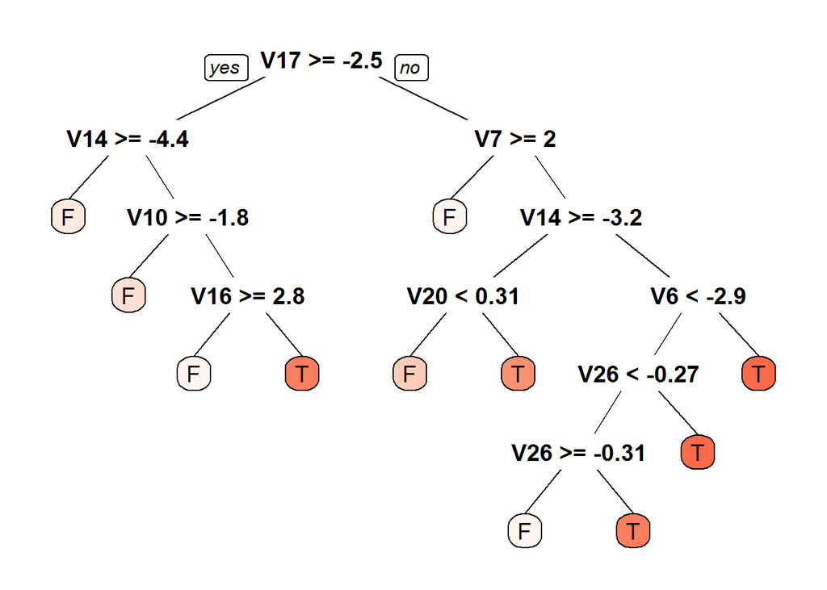

```r
prp(dtree_fit$finalModel, box.palette = "Reds", tweak = 1.2)
```

```r
test_pred <- predict(dtree_fit, newdata = testing)
table(test_pred, testing$Class )
```

```
##
## test_pred     F     T
##         F 56857    21
##         T     6    77
```

```r
confusionMatrix(test_pred, testing$Class )
```

```
## Confusion Matrix and Statistics
##
##           Reference
## Prediction     F     T
##          F 56857    21
##          T     6    77
##
##                Accuracy : 0.9995
##                  95% CI : (0.9993, 0.9997)
##     No Information Rate : 0.9983
##     P-Value [Acc > NIR] : < 2.2e-16
##
##                   Kappa : 0.8506
##  Mcnemar's Test P-Value : 0.007054
##
##             Sensitivity : 0.9999
##             Specificity : 0.7857
##          Pos Pred Value : 0.9996
##          Neg Pred Value : 0.9277
##              Prevalence : 0.9983
##          Detection Rate : 0.9982
##    Detection Prevalence : 0.9985
##       Balanced Accuracy : 0.8928
##
##        'Positive' Class : F
##
```

Prepare the training and testing data frame for Random Forests

```r
set.seed(3033)
intrain <- createDataPartition(y = cc$Class, p=0.1, list = F)
training <- cc[intrain,]
testing <- cc[-intrain,]
```

Prepare the setting to run the training model using 4 CPUs

```r
registerDoParallel(cpu4<- makePSOCKcluster(4))
```

Configuration the settings for 10-fold (10 RF models)

```r
trctrl <- trainControl(method = "repeatedcv", number = 10, repeats = 3)
set.seed(123)
```

Random Forest Model

```r
system.time(
    Mod_rf <- train(Class ~., data = training, method = "rf",
        parms = list(split = "information"),
        trControl=trctrl)
)
```

```
##    user  system elapsed
##   47.33    1.50 1887.30
```

```r
stopCluster(cpu4)
```

Print the Random Forest training model for inspecting Accuracy

```r
print(Mod_rf)
```

```
## Random Forest
##
## 28482 samples
##    30 predictor
##     2 classes: 'F', 'T'
##
## No pre-processing
## Resampling: Cross-Validated (10 fold, repeated 3 times)
## Summary of sample sizes: 25634, 25634, 25634, 25634, 25634, 25634, ...
## Resampling results across tuning parameters:
##
##   mtry  Accuracy   Kappa
##    2    0.9991223  0.6852317
##   16    0.9991574  0.7172984
##   30    0.9990871  0.7021764
##
## Accuracy was used to select the optimal model using the largest value.
## The final value used for the model was mtry = 16.
```

Variable Importance for decising Feature Selection.

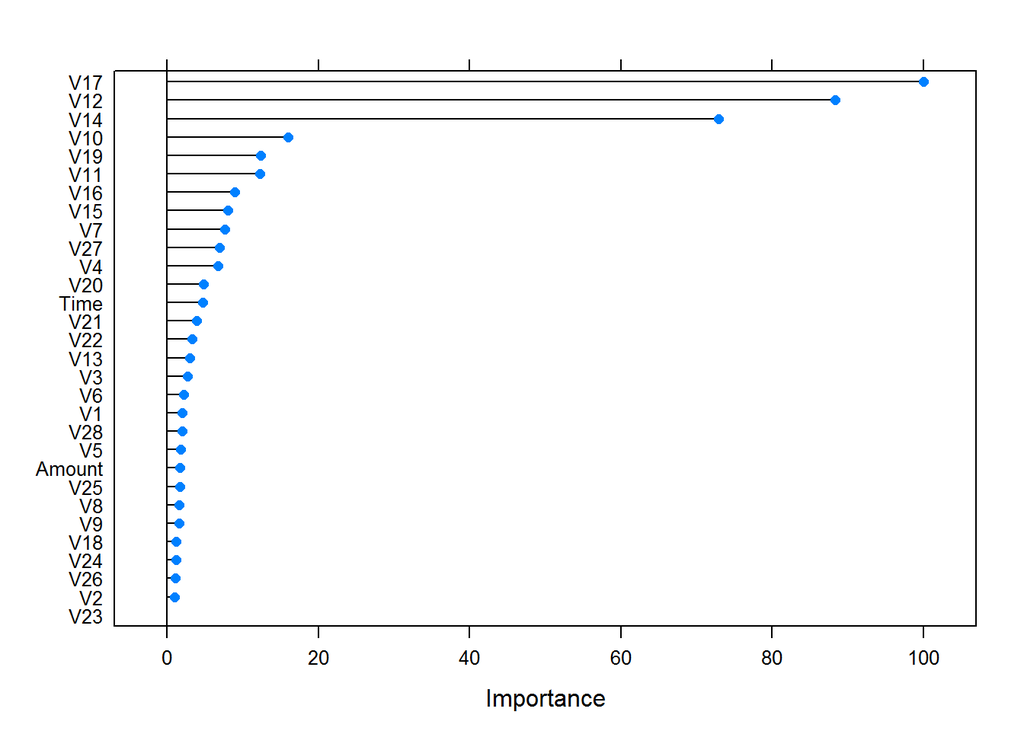

```r
vi <-varImp(Mod_rf)
plot(vi)
```

Allocating 4 CPU for parallel.

```r
rm(Mod_rf)
cpu4 <- makePSOCKcluster(4)
registerDoParallel(cpu4)
```

```r
set.seed(123)
system.time(
    Mod_rf_vi2 <- train(Class ~ V17+V12+V14+V11+V16+V10+V7+V4+V15+V3+V27+V21+V13+V1,
        data = training, method = "rf",
        parms = list(split = "information"),
        trControl=trctrl)
)
```

```
##    user  system elapsed
##   13.87    1.53  759.03
```

```r
stopCluster(cpu4)
```

Print the model

```r
print(Mod_rf_vi2)
```

```
## Random Forest
##
## 28482 samples
##    14 predictor
##     2 classes: 'F', 'T'
##
## No pre-processing
## Resampling: Cross-Validated (10 fold, repeated 3 times)
## Summary of sample sizes: 25634, 25634, 25634, 25634, 25634, 25634, ...
## Resampling results across tuning parameters:
##
##   mtry  Accuracy   Kappa
##    2    0.9991457  0.7106854
##    8    0.9991457  0.7131934
##   14    0.9989701  0.6784200
##
## Accuracy was used to select the optimal model using the largest value.
## The final value used for the model was mtry = 2.
```

```r
rm(Mod_rf_vi2)
set.seed(123)
registerDoParallel(cpu4<-makePSOCKcluster(4))
system.time(
    Mod_rf_vi3 <- train(Class ~ V17+V12+V14+V11+V16+V10,
        data = training, method = "rf",
        parms = list(split = "information"),
        trControl=trctrl)
)
```

```
##    user  system elapsed
##    7.47    1.53  304.70
```

```r
stopCluster(cpu4) ; registerDoSEQ()
```

Print the model

```r
print(Mod_rf_vi3)
```

```
## Random Forest
##
## 28482 samples
##     6 predictor
##     2 classes: 'F', 'T'
##
## No pre-processing
## Resampling: Cross-Validated (10 fold, repeated 3 times)
## Summary of sample sizes: 25634, 25634, 25634, 25634, 25634, 25634, ...
## Resampling results across tuning parameters:
##
##   mtry  Accuracy   Kappa
##   2     0.9991457  0.7165244
##   4     0.9991340  0.7146253
##   6     0.9990286  0.6954117
##
## Accuracy was used to select the optimal model using the largest value.
## The final value used for the model was mtry = 2.
```

## Random Forest Models: 14 vs 6 Features

The 14 vs 6 features of importance were executed on 10% data for training with 4 CPUs and Peak Memory were at 7.5G each. Given that the training data is only on 10% of the real data, a possible underfit is observed where the training models Accuracy are each at 99.91457%

## Manual Feature Selection for Ramdom Forest Models

```r
cc_r<-cbind(setNames(cc[18],'V17'),
        setNames(cc[13],'V12'),
        setNames(cc[15],'V14'),
        setNames(cc[12],'V11'),
        setNames(cc[17],'V16'),
        setNames(cc[8],'V7'),
        setNames(cc[5],'V4'),
        setNames(cc[16],'V15'),
        setNames(cc[11],'V10'),
        setNames(cc[31],'Class'))
```

Prepare the training (80%) and testing (20%) data frame. with the additional number of tree (ntree) setting to 50.

```r
set.seed(3033)
trctrl <- trainControl(method = "repeatedcv", number = 10, repeats = 3)
intrain_r <- createDataPartition(y = cc_r$Class, p=0.8, list = FALSE)
training_r <- cc_r[intrain_r,]
testing_r <- cc_r[-intrain_r,]
set.seed(123)
system.time(
    Mod_rf_vi4 <- train(Class ~ .,
        data = training_r, method = "rf",
        ntree=50,
        trControl=trctrl)
)
```

```
##    user  system elapsed
## 2630.45   35.59 2705.11
```

Print the model

```r
print(Mod_rf_vi4)
```

```
## Random Forest
##
## 227846 samples
##      9 predictor
##      2 classes: 'F', 'T'
##
## No pre-processing
## Resampling: Cross-Validated (10 fold, repeated 3 times)
## Summary of sample sizes: 205061, 205062, 205062, 205062, 205062, 205061, ...
## Resampling results across tuning parameters:
##
##   mtry  Accuracy   Kappa
##   2     0.9995406  0.8543564
##   5     0.9995275  0.8493887
##   9     0.9995041  0.8418944
##
## Accuracy was used to select the optimal model using the largest value.
## The final value used for the model was mtry = 2.
```

Prediction

```r
test_pred_rf2_vi4 <- predict(Mod_rf_vi4, newdata = testing_r)
table(test_pred_rf2_vi4, testing_r$Class )
```

```
##
## test_pred_rf2_vi4     F     T
##                 F 56858    22
##                 T     5    76
```

Confusiion Matrix on 20% testing data with 9 features.

```r
confusionMatrix(test_pred_rf2_vi4, testing_r$Class )
```

```
## Confusion Matrix and Statistics
##
##           Reference
## Prediction     F     T
##          F 56858    22
##          T     5    76
##
##                Accuracy : 0.9995
##                  95% CI : (0.9993, 0.9997)
##     No Information Rate : 0.9983
##     P-Value [Acc > NIR] : < 2.2e-16
##
##                   Kappa : 0.8489
##  Mcnemar's Test P-Value : 0.002076
##
##             Sensitivity : 0.9999
##             Specificity : 0.7755
##          Pos Pred Value : 0.9996
##          Neg Pred Value : 0.9383
##              Prevalence : 0.9983
##          Detection Rate : 0.9982
##    Detection Prevalence : 0.9986
##       Balanced Accuracy : 0.8877
##
##        'Positive' Class : F
##
```

```r
#rm(Mod_rf_vi4)
```

Manually updated the data frame with 17 features for performance and accuracy investigation.

```r
cc_r17<-cbind(setNames(cc[18],'V17'),
        setNames(cc[13],'V12'),
        setNames(cc[15],'V14'),
        setNames(cc[12],'V11'),
        setNames(cc[17],'V16'),
        setNames(cc[11],'V10'),
        setNames(cc[8],'V7'),
        setNames(cc[5],'V4'),
        setNames(cc[16],'V15'),
        setNames(cc[4],'V3'),
        setNames(cc[28],'V27'),
        setNames(cc[22],'V21'),
        setNames(cc[13],'V13'),
        setNames(cc[2],'V1'),
        setNames(cc[1],'Time'),
        setNames(cc[21],'V20'),
        setNames(cc[10],'V9'),
        setNames(cc[31],'Class'))
set.seed(3033)
intrain_r17 <- createDataPartition(y = cc_r17$Class, p= 0.8, list = FALSE)
training_r17 <- cc_r17[intrain_r17,]
testing_r17 <- cc_r17[-intrain_r17,]
set.seed(123)
system.time(
    Mod_rf_vi6 <- train(Class ~ .,
        data = training_r17, method = "rf",
        ntree=50,
        trControl=trctrl)
)
```

```
##    user  system elapsed
## 6175.30   38.20 6221.54
```

Print the Model

```r
print(Mod_rf_vi6)
```

```
## Random Forest
##
## 227846 samples
##     17 predictor
##      2 classes: 'F', 'T'
##
## No pre-processing
## Resampling: Cross-Validated (10 fold, repeated 3 times)
## Summary of sample sizes: 205061, 205062, 205062, 205062, 205062, 205061, ...
## Resampling results across tuning parameters:
##
##   mtry  Accuracy   Kappa
##    2    0.9995201  0.8451434
##    9    0.9995509  0.8569864
##   17    0.9995348  0.8515305
##
## Accuracy was used to select the optimal model using the largest value.
## The final value used for the model was mtry = 9.
```

Prediction

```r
test_pred_rf2_vi6 <- predict(Mod_rf_vi6, newdata = testing_r17)
table(test_pred_rf2_vi6, testing_r17$Class )
```

```
##
## test_pred_rf2_vi6     F     T
##                 F 56858    20
##                 T     5    78
```

Confision Matrix with 17 features manually created

```r
confusionMatrix(test_pred_rf2_vi6, testing_r17$Class )
```

```
## Confusion Matrix and Statistics
##
##           Reference
## Prediction     F     T
##          F 56858    20
##          T     5    78
##
##                Accuracy : 0.9996
##                  95% CI : (0.9994, 0.9997)
##     No Information Rate : 0.9983
##     P-Value [Acc > NIR] : < 2e-16
##
##                   Kappa : 0.8617
##  Mcnemar's Test P-Value : 0.00511
##
##             Sensitivity : 0.9999
##             Specificity : 0.7959
##          Pos Pred Value : 0.9996
##          Neg Pred Value : 0.9398
##              Prevalence : 0.9983
##          Detection Rate : 0.9982
##    Detection Prevalence : 0.9985
##       Balanced Accuracy : 0.8979
##
##        'Positive' Class : F
##
```

## Conclusion

After ML training on Naïve Bayes, Decision Tree and a few Random Forest models, the best model with the best prediction is Random Forest with 17 features of importance manually created given that it has the highest Accuracy and Negatively Predicted Value. Therefore, the Random Forest Model Mod_rf_vi6 was selected as it has the highest Accuracy and Negatively Predicted Value. This selected RF model should be run on machine with multiple CPUs and abundance of memory.